# TUGAS AKHIR TEKNIK PEUBAH GANDA

## Analisis Eksplorasi Data serta Visualisasi Awal

```r
library(dplyr)
library(ggplot2)
library(tidyr)
library(forcats)
```

### Cek Struktur Data & Ringkasan

```r
# Struktur dataset
str(df)
```

```
## tibble [340,620 × 10] (S3: tbl_df/tbl/data.frame)
##  $ KabKot   : chr [1:340620] "Kab. Aceh Barat" "Kab. Aceh Barat" "Kab. Aceh Barat" "Kab. Aceh Barat" ...
##  $ Tahun    : int [1:340620] 2022 2022 2022 2022 2022 2022 2022 2022 2022 2022 ...
##  $ Bulan    : chr [1:340620] "Januari" "Januari" "Januari" "Januari" ...
##  $ Produk   : chr [1:340620] "Beras Premium" "Beras Medium" "Bawang Merah" "Bawang Putih (Bonggol)" ...
##  $ Harga    : num [1:340620] 11429 9979 31000 28636 19409 ...
##  $ Kategori : chr [1:340620] "Beras" "Beras" "Bawang" "Bawang" ...
##  $ KodeBPS  : num [1:340620] 11.1 11.1 11.1 11.1 11.1 ...
##  $ KodeProv : num [1:340620] 11 11 11 11 11 11 11 11 11 11 ...
##  $ NamaProv : chr [1:340620] "Aceh" "Aceh" "Aceh" "Aceh" ...
##  $ Bulan_num: int [1:340620] 1 1 1 1 1 1 1 1 1 1 ...
```

```r
# Ringkasan statistik numerik
summary(df)
```

```
##     KabKot              Tahun         Bulan              Produk
##  Length:340620      Min.   :2022   Length:340620      Length:340620
##  Class :character   1st Qu.:2022   Class :character   Class :character
##  Mode  :character   Median :2023   Mode  :character   Mode  :character
##                     Mean   :2023
##                     3rd Qu.:2024
##                     Max.   :2025
##      Harga          Kategori            KodeBPS         KodeProv
##  Min.   :     1   Length:340620      Min.   :11.01   Min.   :11.0
##  1st Qu.: 15846   Class :character   1st Qu.:17.09   1st Qu.:17.0
##  Median : 25790   Mode  :character   Median :35.21   Median :35.0
##  Mean   : 35798                      Mean   :43.81   Mean   :43.6
##  3rd Qu.: 42000                      3rd Qu.:71.01   3rd Qu.:71.0
##  Max.   :204423                      Max.   :92.71   Max.   :92.0
##    NamaProv           Bulan_num
##  Length:340620      Min.   : 1.000
##  Class :character   1st Qu.: 3.000
##  Mode  :character   Median : 6.000
##                     Mean   : 6.289
##                     3rd Qu.: 9.000
##                     Max.   :12.000
```

```r
# Jumlah NA per kolom
colSums(is.na(df))
```

```
##    KabKot     Tahun     Bulan    Produk     Harga  Kategori   KodeBPS  KodeProv
##         0         0         0         0         0         0         0         0
##  NamaProv Bulan_num
##         0         0
```

*Ringkasan Statistik Utama* Tahun Rentang: 2022 – 2025 Median: 2023 Data relatif merata di tiap tahun (tidak ada missing).

Harga Min: 1 Mean: 35.798 Median: 25.790 Max: 204.423

Harga sangat variatif antar komoditas, mencakup komoditas bawang/cabai (tinggi), beras, komoditas murah (contoh sayuran tertentu atau satuan gram).

### Distribusi Jumlah Data per Produk

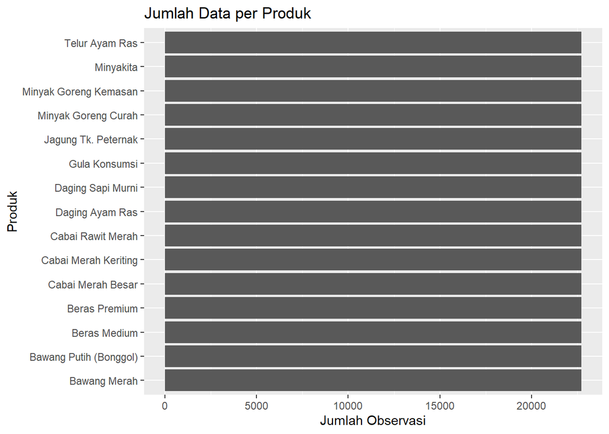

```r
df %>%
  count(Produk, sort = TRUE) %>%
  ggplot(aes(x = fct_reorder(Produk, n), y = n)) +
  geom_col() +
  coord_flip() +
  labs(title = "Jumlah Data per Produk",
       x = "Produk",
       y = "Jumlah Observasi")
```

Ke-15 produk ini memiliki jumlah observasi (data) yang sangat seragam dan masing-masing melebihi 20.000 observasi.